# TidyTemplate

2020-11-03

# TidyTuesday [2020-11-03]

```r
library(tidyverse)
library(tidytuesdayR)
library(scales)
library(ggthemes)
theme_set(theme_light())
```

# Data

```r
tt <- tt_load('2020-11-03')
```

```
## ---- Compiling #TidyTuesday Information for 2020-11-03 ----
## --- There is 1 file available ---
##
##
## ── Downloading files ───────────────────────────────────────────────────────────
##
##   1 of 1: "ikea.csv"
```

```r
ikea <- tt$ikea

glimpse(ikea)
```

```
## Rows: 3,694
## Columns: 14
## $ ...1              <dbl> 0, 1, 2, 3, 4, 5, 6, 7, 8, 9, 10, 11, 12, 13, 14, 15…
## $ item_id           <dbl> 90420332, 368814, 9333523, 80155205, 30180504, 10122…
## $ name              <chr> "FREKVENS", "NORDVIKEN", "NORDVIKEN / NORDVIKEN", "S…
## $ category          <chr> "Bar furniture", "Bar furniture", "Bar furniture", "…
## $ price             <dbl> 265, 995, 2095, 69, 225, 345, 129, 195, 129, 2176, 1…
## $ old_price         <chr> "No old price", "No old price", "No old price", "No …
## $ sellable_online   <lgl> TRUE, FALSE, FALSE, TRUE, TRUE, TRUE, TRUE, TRUE, TR…
## $ link              <chr> "https://www.ikea.com/sa/en/p/frekvens-bar-table-in-…
## $ other_colors      <chr> "No", "No", "No", "Yes", "No", "No", "No", "No", "No…
## $ short_description <chr> "        Bar table, in/outdoor,          51x51 cm", …
## $ designer          <chr> "Nicholai Wiig Hansen", "Francis Cayouette", "Franci…
## $ depth             <dbl> NA, NA, NA, 50, 60, 45, 44, 50, 44, NA, 44, 45, 47, …
## $ height            <dbl> 99, 105, NA, 100, 43, 91, 95, NA, 95, NA, 103, 102, …
## $ width             <dbl> 51, 80, NA, 60, 74, 40, 50, 50, 50, NA, 52, 40, 46, …
```

```r
ikea <- ikea %>%
  select(-...1) %>%
  mutate(price_usd = price * .27, # change SAR to USD
         short_description = str_squish(short_description)) %>%
  add_count(category, name = "category_total")
```

# Readme

Take a look at the readme for the weekly data to get insight on the dataset. This includes a data dictionary, source, and a link to an article on the data.

```r
tt
```

# Glimpse Data

Take an initial look at the format of the data available.

```r
map(tt, glimpse)
```

```
## Rows: 3,694
## Columns: 14
## $ ...1              <dbl> 0, 1, 2, 3, 4, 5, 6, 7, 8, 9, 10, 11, 12, 13, 14, 15…
## $ item_id           <dbl> 90420332, 368814, 9333523, 80155205, 30180504, 10122…
## $ name              <chr> "FREKVENS", "NORDVIKEN", "NORDVIKEN / NORDVIKEN", "S…
## $ category          <chr> "Bar furniture", "Bar furniture", "Bar furniture", "…
## $ price             <dbl> 265, 995, 2095, 69, 225, 345, 129, 195, 129, 2176, 1…
## $ old_price         <chr> "No old price", "No old price", "No old price", "No …
## $ sellable_online   <lgl> TRUE, FALSE, FALSE, TRUE, TRUE, TRUE, TRUE, TRUE, TR…
## $ link              <chr> "https://www.ikea.com/sa/en/p/frekvens-bar-table-in-…
## $ other_colors      <chr> "No", "No", "No", "Yes", "No", "No", "No", "No", "No…
## $ short_description <chr> "        Bar table, in/outdoor,          51x51 cm", …
## $ designer          <chr> "Nicholai Wiig Hansen", "Francis Cayouette", "Franci…
## $ depth             <dbl> NA, NA, NA, 50, 60, 45, 44, 50, 44, NA, 44, 45, 47, …
## $ height            <dbl> 99, 105, NA, 100, 43, 91, 95, NA, 95, NA, 103, 102, …
## $ width             <dbl> 51, 80, NA, 60, 74, 40, 50, 50, 50, NA, 52, 40, 46, …
```

```
## $ikea
## # A tibble: 3,694 × 14
##     ...1  item_id name            category price old_price sellable_online link
##    <dbl>    <dbl> <chr>           <chr>    <dbl> <chr>     <lgl>           <chr>
##  1     0 90420332 FREKVENS        Bar fur…   265 No old p… TRUE            http…
##  2     1   368814 NORDVIKEN       Bar fur…   995 No old p… FALSE           http…
##  3     2  9333523 NORDVIKEN / NO… Bar fur…  2095 No old p… FALSE           http…
##  4     3 80155205 STIG            Bar fur…    69 No old p… TRUE            http…
##  5     4 30180504 NORBERG         Bar fur…   225 No old p… TRUE            http…
##  6     5 10122647 INGOLF          Bar fur…   345 No old p… TRUE            http…
##  7     6 70404875 FRANKLIN        Bar fur…   129 No old p… TRUE            http…
##  8     7 60155602 DALFRED         Bar fur…   195 No old p… TRUE            http…
##  9     8 50406465 FRANKLIN        Bar fur…   129 No old p… TRUE            http…
## 10     9 69304221 EKEDALEN / EKE… Bar fur…  2176 SR 2,375  TRUE            http…
## # ℹ 3,684 more rows
## # ℹ 6 more variables: other_colors <chr>, short_description <chr>,
## #   designer <chr>, depth <dbl>, height <dbl>, width <dbl>
```

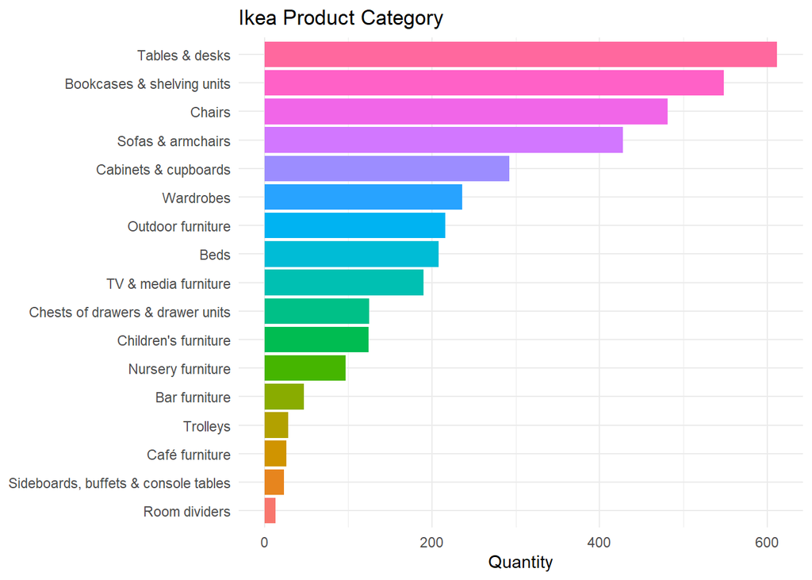

```r
ikea %>%
  count(category, sort = TRUE) %>%
  mutate(category = fct_reorder(category, n)) %>%
  ggplot(aes(n, category, fill = category)) +
  geom_col() +
  xlab("Quantity") +
  ylab(NULL) +
  ggtitle("Ikea Product Category") +
  theme_minimal() +
  theme(legend.position = "none")
```

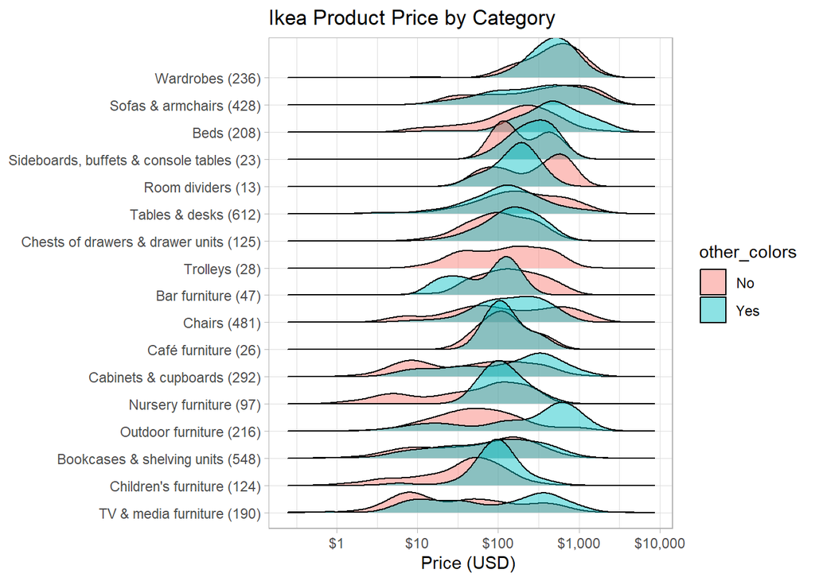

```r
library(glue)

library(ggridges)


ikea %>%
  add_count(category, name = "category_total") %>% # add_count() and add_tally() are equivalents to count() and tally() but use mutate() instead of summarise() so that they add a new column with group-wise counts.
  mutate(category = glue("{category} ({category_total})"),
         category = fct_reorder(category, price_usd,)) %>%
  ggplot(aes(price_usd, category, fill = other_colors)) +
  geom_density_ridges(alpha = .45) +
  # geom_jitter(width = -0, height = .1, alpha = .25) +
  scale_x_log10(labels = dollar) +
  ylab(NULL) +
  xlab("Price (USD) ") +
  ggtitle("Ikea Product Price by Category")
```

Exploring the relation between price, category and `other_color` would be beneficial if one were to develop a predictive model. - On log scale in price: The data ain’t normally distributed; log-scale makes it easier to see the bi-modality of the price for each category.

### Exploring common name and category

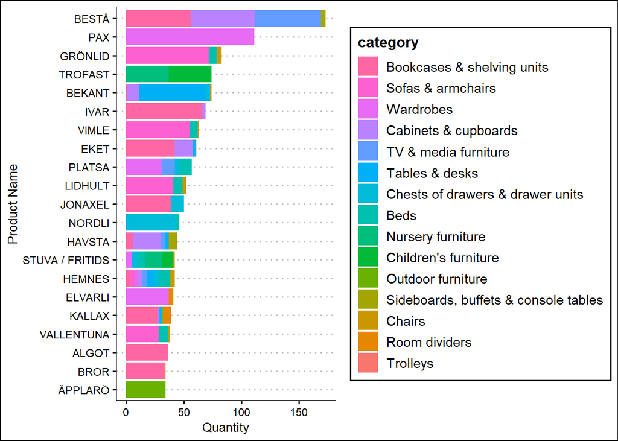

```r
ikea %>%
  mutate(name = fct_lump(name, 20)) %>% # fct_lump() will lump all but the top 20 most common names into "Other"
  filter(!name == "Other") %>%
  count(name, category ,sort = TRUE) %>%
  mutate(name = fct_reorder(name, n, sum),
         category = fct_reorder(category, n, sum)) %>%
  ggplot(aes(n, name, fill = category)) +
  geom_col() +
  scale_fill_discrete(guide = guide_legend(reverse = TRUE)) +
  labs(x = "Quantity",
       y = "Product Name") +
  theme_clean()
```

Variations of prodcuts:

The variation of product name is explained by the wide range of family of products under each name. For instance, Besta is a storage system that comprises different types of storage selections.

### Tinkering with short description (dimensions)

```r
ikea %>%
  separate(short_description,
           c("main_description", "rest"),
           ", ",
           extra = "merge",
           fill = "right") %>%
  extract(rest,
          "dimension_cm",
          "([\\d\\-xX]+) cm",
          remove = FALSE) %>%
  unite(category_and_description, category, main_description, sep = " - ") %>%
  count(category_and_description, sort = TRUE)
```

```
## # A tibble: 1,012 × 2
##    category_and_description                       n
##    <chr>                                      <int>
##  1 Tables & desks - Table                       127
##  2 Wardrobes - Wardrobe                         121
##  3 Chairs - Table and 4 chairs                   83
##  4 Tables & desks - Table and 4 chairs           83
##  5 Chairs - Chair                                53
##  6 Bookcases & shelving units - Shelving unit    45
##  7 Chairs - Table and 6 chairs                   39
##  8 Tables & desks - Table and 6 chairs           39
##  9 Sofas & armchairs - Corner sofa               33
## 10 Sofas & armchairs - 3-seat sofa               32
## # ℹ 1,002 more rows
```

### Volume

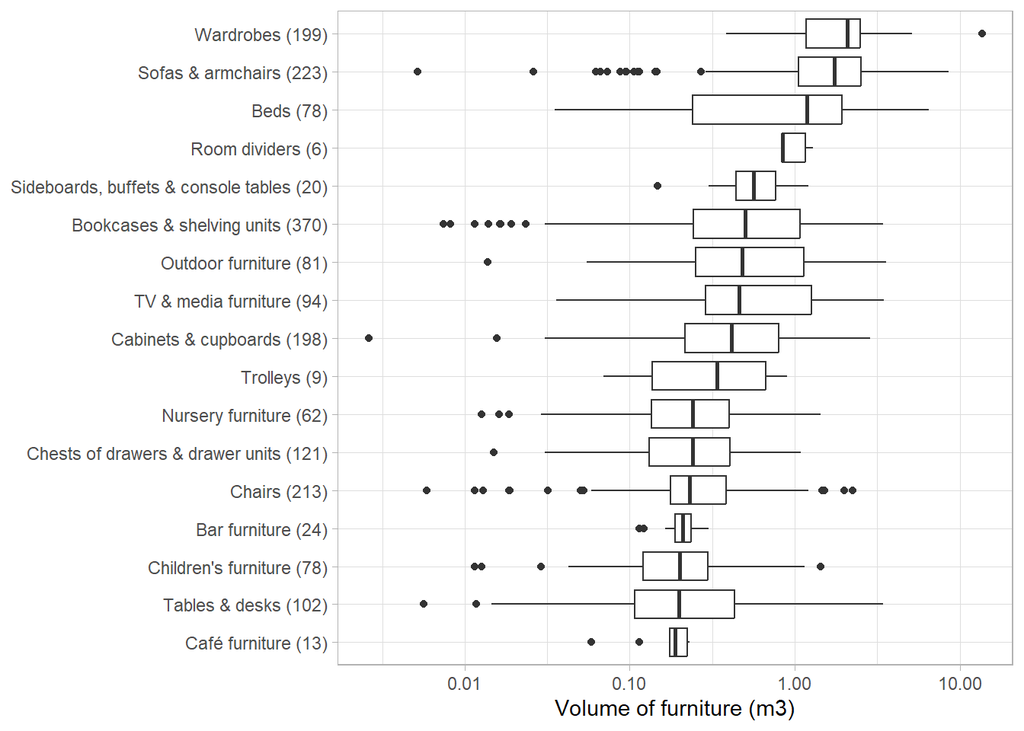

```r
ikea_volume <- ikea %>%
  select(item_id, name, category, short_description, price_usd, depth, height, width) %>%
  mutate(volume_m3 = depth * height * width / 1e6) %>% # calculate vol for products with all three dimensions
  filter(!is.na(volume_m3),
         volume_m3 > .001) %>%
  arrange(desc(volume_m3)) %>%
  add_count(category, name = "category_total")




ikea_volume %>%
  mutate(category = glue("{category} ({category_total})"),
         category = fct_reorder(category, volume_m3)) %>%
  ggplot(aes(volume_m3, category)) +
  geom_boxplot() +
  scale_x_log10() +
  labs(x =  "Volume of furniture (m3)",
       y = NULL
       )
```

```r
ikea_volume
```

```
## # A tibble: 1,891 × 10
##     item_id name    category      short_description price_usd depth height width
##       <dbl> <chr>   <chr>         <chr>                 <dbl> <dbl>  <dbl> <dbl>
##  1 19300107 PAX     Wardrobes     Wardrobe, 276x21…     1453.   210    236   275
##  2 69254810 GRÖNLID Sofas & armc… U-shaped sofa, 6…     1775.   252    104   327
##  3 89256610 GRÖNLID Sofas & armc… U-shaped sofa, 6…     2403    252    104   327
##  4 59193723 KIVIK   Sofas & armc… U-shaped sofa, 7…     2240.   257     83   368
##  5 49252949 KIVIK   Sofas & armc… U-shaped sofa, 6…     1862.   257     83   328
##  6 69285294 VIMLE   Sofas & armc… U-shaped sofa, 6…     2267.   249     83   327
##  7 29277639 LIDHULT Beds          Corner sofa-bed,…     2588.   164    102   387
##  8 79277632 LIDHULT Sofas & armc… Corner sofa-bed,…     2588.   164    102   387
##  9 69257328 LIDHULT Sofas & armc… 4-seat sofa           1700.   164    102   369
## 10 49257348 LIDHULT Sofas & armc… 4-seat sofa           2092.   164    102   369
## # ℹ 1,881 more rows
## # ℹ 2 more variables: volume_m3 <dbl>, category_total <int>
```

What is the price per cubic metre?

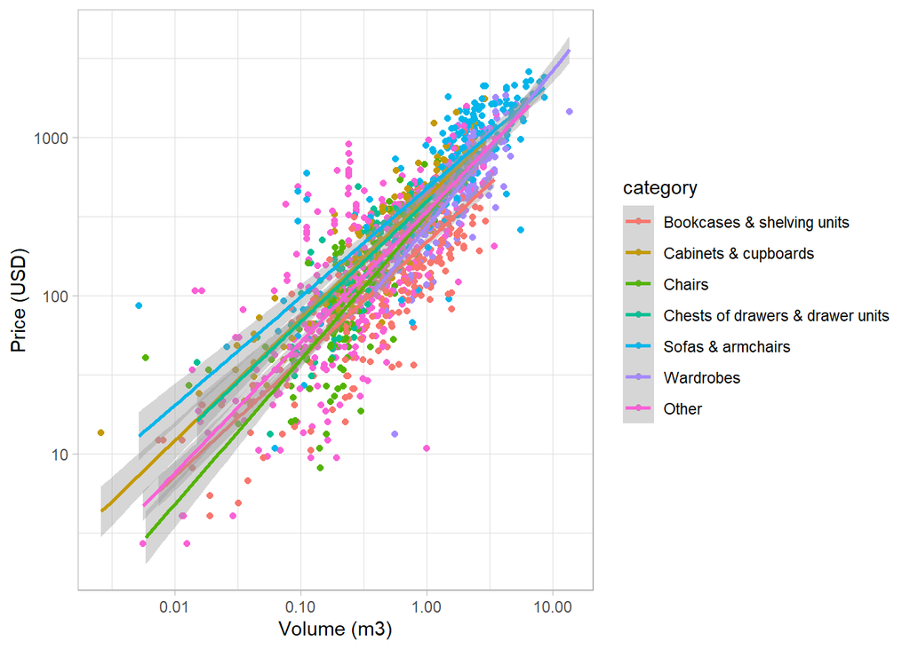

```r
ikea_volume %>%
  mutate(category = fct_lump(category, 6)) %>%
  ggplot(aes(volume_m3, price_usd, color = category)) +
  geom_point() +
  geom_smooth(method = "lm") +
  scale_x_log10()+
  scale_y_log10() +
  labs(x ="Volume (m3)",
       y = "Price (USD)")
```

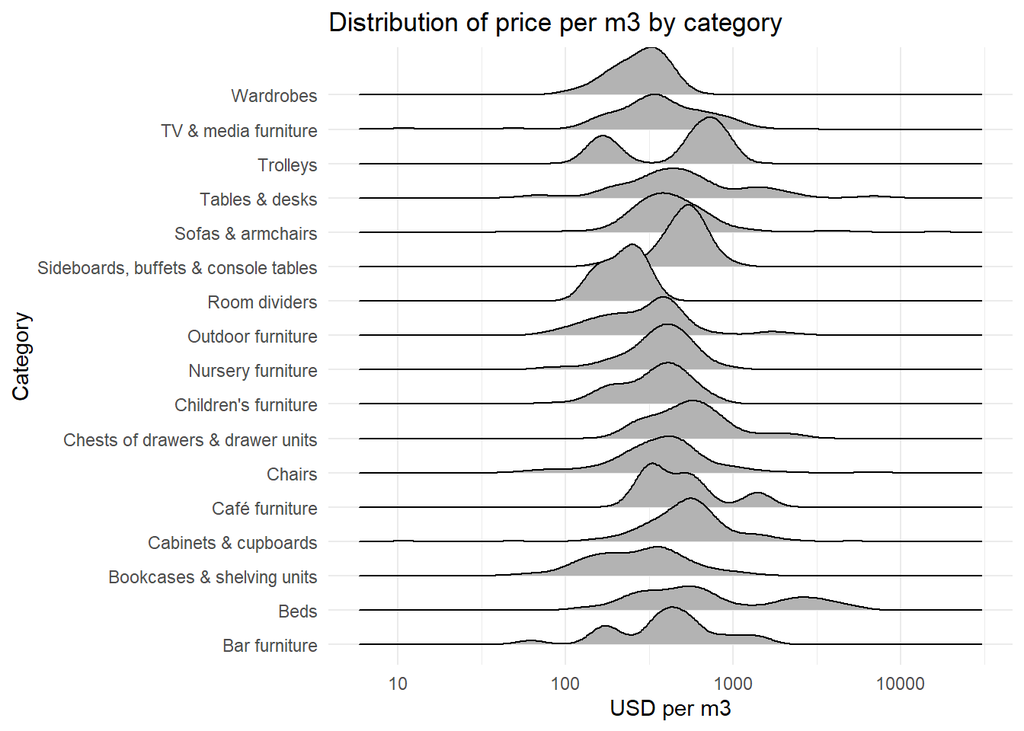

```r
ikea_volume %>%
  mutate(dollar_per_m3 = price_usd / volume_m3) %>%
  arrange(desc(dollar_per_m3)) %>%
  ggplot(aes(dollar_per_m3, category)) +
  geom_density_ridges() +
  scale_x_log10() +
  xlab("USD per m3") +
  ylab("Category") +
  ggtitle("Distribution of price per m3 by category") +
  theme_minimal()
```